# Maine Coastal Current Flux Transport

- Show All Code
- Hide All Code
- View Source

Maine Coastal Current PCA/EOF with FVCOM

Published

October 20, 2025

```r
{
  library(raster)
  library(sf)
  library(fvcom)
  library(ncdf4)
  library(tidyverse)
  library(gmRi)
  library(patchwork)
  library(rnaturalearth)
  library(showtext)
  # Cyclic color palettes in scico
  # From: https://www.fabiocrameri.ch/colourmaps/
  library(scico)
  library(legendry)
}

# namespace conflicts
conflicted::conflict_prefer("select", "dplyr")
conflicted::conflict_prefer("filter", "dplyr")


# Set the theme
theme_set(theme_gmri_simple())

# Project paths
lob_ecol_path <- cs_path("mills", "Projects/Lobster ECOL")
fvcom_path    <- cs_path("res", "FVCOM/Lobster-ECOL")
poly_paths    <- cs_path("mills", "Projects/Lobster ECOL/Spatial_Defs")

# Shapefiles
new_england <- ne_states("united states of america", returnclass = "sf") %>%
  filter(postal %in% c("VT", "ME", "RI", "MA", "CT", "NH", "NY", "MD", "VA", "NJ", "DE", "NC", "PA", "WV"))
canada <- ne_states("canada", returnclass = "sf")

# # # Support functions for FVCOM
source(here::here("R/FVCOM_Support.R"))
```

```r
# Use GMRI style
use_gmri_style_rmd()
```

```r
# List the FVCOM file names we have locally (on Box)
fvcom_surfbot_files <- setNames(
  list.files(fvcom_path, full.names = T, pattern = ".nc"),
  str_remove(list.files(fvcom_path, full.names = F, pattern = ".nc"), ".nc"))


# Open one file to build the mesh and get indexing information
gom3_early <- nc_open(fvcom_surfbot_files[[1]])
# So the data is daily...
# ncvar_get(gom3_early, varid = "surface_v", start = c(1,1), count = c(1,-1))


# Get the mesh itself as a simple feature collection
gom3_mesh <- get_mesh_geometry(gom3_early, what = 'lonlat')
```

# Flux Transport of Maine Coastal Current Information from FVCOM

Alongshore transport of water during the summer months is thought to be favorable for lobster recruitment, a species which primarily spawns during this time of year.

In `AlongshoreOffshore_MCC_EOF` I explored using principal component analyses as a means to get some index of the connectivity between the eastern and western branches of the Maine Coastal Current.

After exploring those thoroughly, and getting feedback from the team it was recommended that we approach the question with a more direct measurement of alongshore and offshore Flux using a transect.

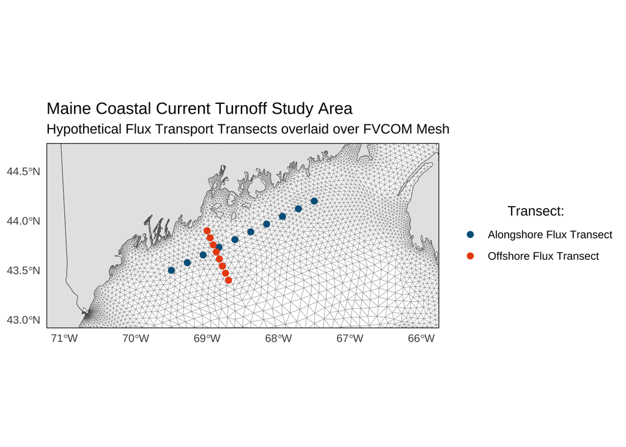

```r
# Build transects from equally spaced points in an alongshore and offshore direction
alongshore_transect <- data.frame(
      lon = seq(-69.5, -67.5, length.out = 10),
      lat = seq(43.5, 44.2, length.out = 10)) %>%
  st_as_sf(coords = c("lon", "lat"), crs = st_crs(4326), remove = F)
offshore_transect <- data.frame(
      lon = seq(-69, -68.7, length.out = 8),
      lat = seq(43.9, 43.4, length.out = 8)) %>%
  st_as_sf(coords = c("lon", "lat"), crs = st_crs(4326), remove = F)

# Map the transects:
ggplot() +
  geom_sf(data = gom3_mesh, color = "black", alpha = 0.9, fill = "transparent", linewidth = 0.05) +
  geom_sf(data = new_england) +
  geom_sf(data = canada) +
  geom_sf(data = alongshore_transect, aes(color = "Alongshore Flux Transect"), size = 2) +
  geom_sf(data = offshore_transect, aes(color = "Offshore Flux Transect"), size = 2) +
  theme_classic() +
  scale_color_gmri() +
  map_theme() +
  coord_sf(
    xlim = c(-71, -66),
    ylim = c(43, 44.7),
    expand = T) +
  labs(
    title = "Maine Coastal Current Turnoff Study Area",
    subtitle = "Hypothetical Flux Transport Transects overlaid over FVCOM Mesh",
    color = "Transect:")
```

For each location along the transect, we want vertically integrated current velocites (eastward ua, and northward va <- double-check names).

The points along the transect will follow a line, and thus not match the FVCOM mesh structure. This means we will need to get interpolated values using nearby or surrounding locations,

After checking back in with Zhuomin, she confirmed that we will need “zones” along a transect and not points. Here is what that would look like:

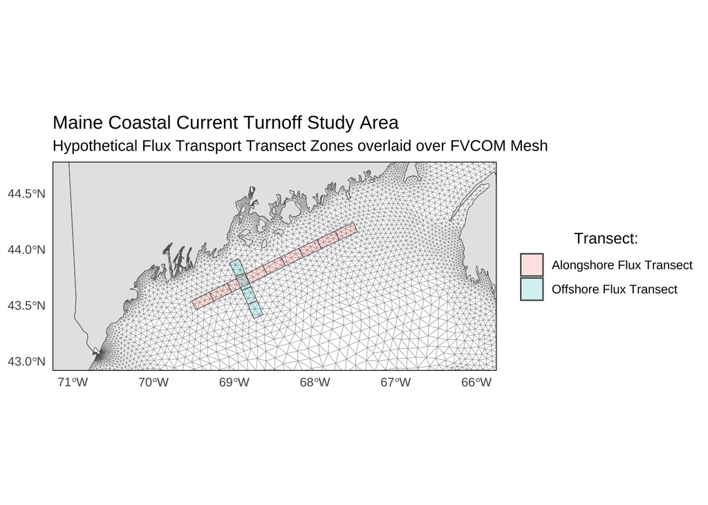

```r
# Set the endpoints
start <- st_point(c(-69.5, 43.5))
end <- st_point(c(-67.5, 44.2))

line <- st_sfc(st_linestring(rbind(st_coordinates(start), st_coordinates(end))), crs = 4326)

# reproject to meters for equal spacing
line_m <- st_transform(line, 32619)  # UTM zone 19N for NE US

# generate equally spaced points (say every 5 km)
n_points <- 10
points_m <- st_line_sample(line_m, sample = seq(0, 1, length.out = n_points))


# Convert to coordinates
coords <- st_coordinates(points_m)

# Calculate segment vectors
seg_vecs <- diff(coords)  # differences between points

# Unit direction vector for each segment
seg_dirs <- seg_vecs / sqrt(rowSums(seg_vecs^2))

# Perpendicular vector (to the left of transect)
perp_dirs <- cbind(-seg_dirs[,2], seg_dirs[,1])

# Define transect width (in meters, e.g., 1000 m)
width <- 10000

# Create polygons between pairs of centerpoints
polys <- list()
for (i in 1:(nrow(coords)-1)) {
  p1 <- coords[i,]
  p2 <- coords[i+1,]

  # corners offset by perpendicular vector
  poly_coords <- rbind(
    p1 + perp_dirs[i,] * width/2,
    p2 + perp_dirs[i,] * width/2,
    p2 - perp_dirs[i,] * width/2,
    p1 - perp_dirs[i,] * width/2,
    p1 + perp_dirs[i,] * width/2
  )

  polys[[i]] <- st_polygon(list(poly_coords))
}

# Convert to simple features collection
alongshore_transect_zones_m <- st_sfc(polys, crs = st_crs(line_m))
alongshore_transect_zones <- st_transform(alongshore_transect_zones_m, 4326)


##### Repeat for offshore transport
# Set the endpoints
start <- st_point(c(-69, 43.9))
end <- st_point(c(-68.7, 43.4))

line <- st_sfc(st_linestring(rbind(st_coordinates(start), st_coordinates(end))), crs = 4326)

# reproject to meters for equal spacing
line_m <- st_transform(line, 32619)  # UTM zone 19N for NE US

# generate equally spaced points (say every 5 km)
n_points <- 5
points_m <- st_line_sample(line_m, sample = seq(0, 1, length.out = n_points))


# Convert to coordinates
coords <- st_coordinates(points_m)

# Calculate segment vectors
seg_vecs <- diff(coords)  # differences between points

# Unit direction vector for each segment
seg_dirs <- seg_vecs / sqrt(rowSums(seg_vecs^2))

# Perpendicular vector (to the left of transect)
perp_dirs <- cbind(-seg_dirs[,2], seg_dirs[,1])

# Define transect width (in meters, e.g., 1000 m)
width <- 10000

# Create polygons between pairs of centerpoints
polys <- list()
for (i in 1:(nrow(coords)-1)) {
  p1 <- coords[i,]
  p2 <- coords[i+1,]

  # corners offset by perpendicular vector
  poly_coords <- rbind(
    p1 + perp_dirs[i,] * width/2,
    p2 + perp_dirs[i,] * width/2,
    p2 - perp_dirs[i,] * width/2,
    p1 - perp_dirs[i,] * width/2,
    p1 + perp_dirs[i,] * width/2
  )

  polys[[i]] <- st_polygon(list(poly_coords))
}

# Convert to simple features collection
offshore_transect_zones_m <- st_sfc(polys, crs = st_crs(line_m))
offshore_transect_zones <- st_transform(offshore_transect_zones_m, 4326)




ggplot() +
  geom_sf(data = gom3_mesh, color = "black", alpha = 0.9, fill = "transparent", linewidth = 0.05) +
  geom_sf(data = new_england) +
  geom_sf(data = canada) +
  geom_sf(data = alongshore_transect_zones,  aes(fill = "Alongshore Flux Transect"), alpha = 0.2) +
  geom_sf(data = offshore_transect_zones, aes(fill = "Offshore Flux Transect"), alpha = 0.2) +
  theme_classic() +
  scale_color_gmri() +
  map_theme() +
  coord_sf(
    xlim = c(-71, -66),
    ylim = c(43, 44.7),
    expand = T) +
  labs(
    title = "Maine Coastal Current Turnoff Study Area",
    subtitle = "Hypothetical Flux Transport Transect Zones overlaid over FVCOM Mesh",
    fill = "Transect:")
```

```r
# Load an FVCOM file that has the ua, uv values (can be monthly)
```